# A7

Author

Lauren Hughes

Published

February 27, 2026

## Loading Libraries

```r
library(dplyr)
library(ggplot2)
```

## Loading Data

```r
# If your computer isn't in English, uncomment the line below:
# Sys.setlocale("LC_ALL", "English")

ks <- read.csv("ks-projects-201801.csv")

glimpse(ks)
```

```
Rows: 378,661
Columns: 15
$ ID               <int> 1000002330, 1000003930, 1000004038, 1000007540, 10000…
$ name             <chr> "The Songs of Adelaide & Abullah", "Greeting From Ear…
$ category         <chr> "Poetry", "Narrative Film", "Narrative Film", "Music"…
$ main_category    <chr> "Publishing", "Film & Video", "Film & Video", "Music"…
$ currency         <chr> "GBP", "USD", "USD", "USD", "USD", "USD", "USD", "USD…
$ deadline         <chr> "2015-10-09", "2017-11-01", "2013-02-26", "2012-04-16…
$ goal             <dbl> 1000, 30000, 45000, 5000, 19500, 50000, 1000, 25000, …
$ launched         <chr> "2015-08-11 12:12:28", "2017-09-02 04:43:57", "2013-0…
$ pledged          <dbl> 0.00, 2421.00, 220.00, 1.00, 1283.00, 52375.00, 1205.…
$ state            <chr> "failed", "failed", "failed", "failed", "canceled", "…
$ backers          <int> 0, 15, 3, 1, 14, 224, 16, 40, 58, 43, 0, 100, 0, 0, 7…
$ country          <chr> "GB", "US", "US", "US", "US", "US", "US", "US", "US",…
$ usd.pledged      <dbl> 0.00, 100.00, 220.00, 1.00, 1283.00, 52375.00, 1205.0…
$ usd_pledged_real <dbl> 0.00, 2421.00, 220.00, 1.00, 1283.00, 52375.00, 1205.…
$ usd_goal_real    <dbl> 1533.95, 30000.00, 45000.00, 5000.00, 19500.00, 50000…
```

## Processing Data

```r
ks <- ks |>
  mutate(
    deadline_date   = as.Date(deadline),
    launched_date   = as.Date(launched),
    deadline_year   = format(deadline_date, "%Y"),
    launched_year   = format(launched_date, "%Y")
  )

glimpse(ks)
```

```
Rows: 378,661
Columns: 19
$ ID               <int> 1000002330, 1000003930, 1000004038, 1000007540, 10000…
$ name             <chr> "The Songs of Adelaide & Abullah", "Greeting From Ear…
$ category         <chr> "Poetry", "Narrative Film", "Narrative Film", "Music"…
$ main_category    <chr> "Publishing", "Film & Video", "Film & Video", "Music"…
$ currency         <chr> "GBP", "USD", "USD", "USD", "USD", "USD", "USD", "USD…
$ deadline         <chr> "2015-10-09", "2017-11-01", "2013-02-26", "2012-04-16…
$ goal             <dbl> 1000, 30000, 45000, 5000, 19500, 50000, 1000, 25000, …
$ launched         <chr> "2015-08-11 12:12:28", "2017-09-02 04:43:57", "2013-0…
$ pledged          <dbl> 0.00, 2421.00, 220.00, 1.00, 1283.00, 52375.00, 1205.…
$ state            <chr> "failed", "failed", "failed", "failed", "canceled", "…
$ backers          <int> 0, 15, 3, 1, 14, 224, 16, 40, 58, 43, 0, 100, 0, 0, 7…
$ country          <chr> "GB", "US", "US", "US", "US", "US", "US", "US", "US",…
$ usd.pledged      <dbl> 0.00, 100.00, 220.00, 1.00, 1283.00, 52375.00, 1205.0…
$ usd_pledged_real <dbl> 0.00, 2421.00, 220.00, 1.00, 1283.00, 52375.00, 1205.…
$ usd_goal_real    <dbl> 1533.95, 30000.00, 45000.00, 5000.00, 19500.00, 50000…
$ deadline_date    <date> 2015-10-09, 2017-11-01, 2013-02-26, 2012-04-16, 2015…
$ launched_date    <date> 2015-08-11, 2017-09-02, 2013-01-12, 2012-03-17, 2015…
$ deadline_year    <chr> "2015", "2017", "2013", "2012", "2015", "2016", "2014…
$ launched_year    <chr> "2015", "2017", "2013", "2012", "2015", "2016", "2014…
```

## Initial Calculations

```r
total_projects    <- nrow(ks)
num_successful    <- sum(ks$state == "successful")
num_failed        <- sum(ks$state == "failed")
pct_failed        <- round((num_failed / total_projects) * 100, 2)
```

There are 378661 projects in the dataset. Out of all of these, 133956 are marked as “successful” & 197719 are marked as “failed”. The percentage of projects marked as “failed” is 52.22%.

## Largest Failure

```r
largest_nonsuccess <- ks |>
  filter(state != "successful") |>
  filter(usd_pledged_real == max(usd_pledged_real, na.rm = TRUE))

largest_nonsuccess |> select(name, state, usd_pledged_real)
```

```
                                                     name     state
1 The Skarp Laser Razor: 21st Century Shaving (Suspended) suspended
  usd_pledged_real
1          4005111
```

The project with the highest pledged amount among non-successful projects is **“The Skarp Laser Razor: 21st Century Shaving (Suspended)”**, which raised $4,005,111 USD but was ultimately marked as “suspended”. According to Wikipedia, the Skarp Laser Razor was a shaving device that claimed to use a laser instead of a traditional blade. Kickstarter suspended the campaign mid-run after concluding the team lacked a decently functioning prototype.

## Project State

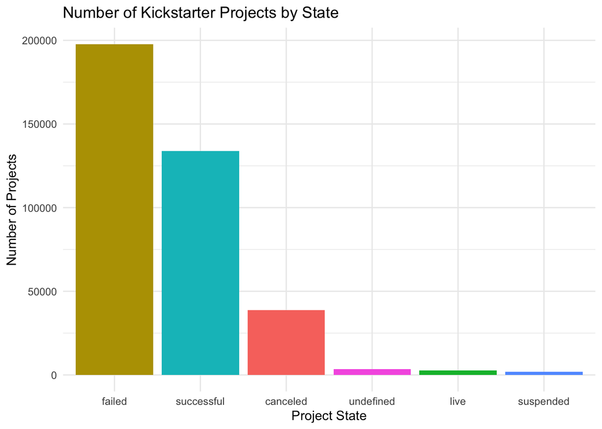

```r
state_summary <- ks |>
  group_by(state) |>
  summarize(count = n())

ggplot(state_summary, aes(x = reorder(state, -count), y = count, fill = state)) +
  geom_bar(stat = "identity") +
  labs(
    title = "Number of Kickstarter Projects by State",
    x     = "Project State",
    y     = "Number of Projects",
    fill  = "State"
  ) +
  theme_minimal() +
  theme(legend.position = "none")
```

The bar chart shows that “failed” is actually the most common project state, followed by “successful”. More Kickstarter projects fail than succeed. The remaining states (canceled, live, suspended, undef) each make up a relatively small share of all projects.

## Yearly Summary

```r
yearly_summary <- ks |>
  group_by(launched_year) |>
  summarize(
    count           = n(),
    percent_success = round(sum(state == "successful") / n() * 100, 2),
    median_pledged  = median(usd_pledged_real, na.rm = TRUE)
  )

print(yearly_summary)
```

```
# A tibble: 11 × 4
   launched_year count percent_success median_pledged
   <chr>         <int>           <dbl>          <dbl>
 1 1970              7             0              0
 2 2009           1329            43.6          580
 3 2010          10519            43.7          780
 4 2011          26237            46.4         1021
 5 2012          41165            43.5         1128
 6 2013          44851            43.3         1453
 7 2014          67745            31.2          420
 8 2015          77300            27.1          222
 9 2016          57184            32.8          501
10 2017          52200            35.4          632
11 2018            124             0             54.3
```

**Decision notes:** I used `launched_year` rather than `deadline_year` because the launch year better represents when a project entered the platform and was active. For `percent_success`, I calculated the percentage of projects with state == “successful” out of all projects launched that year — this includes canceled, suspended, and other states. For the pledge summary, I used `median_pledged` (median of `usd_pledged_real`) because the median is more robust to the extreme outliers that are common in crowdfunding data.

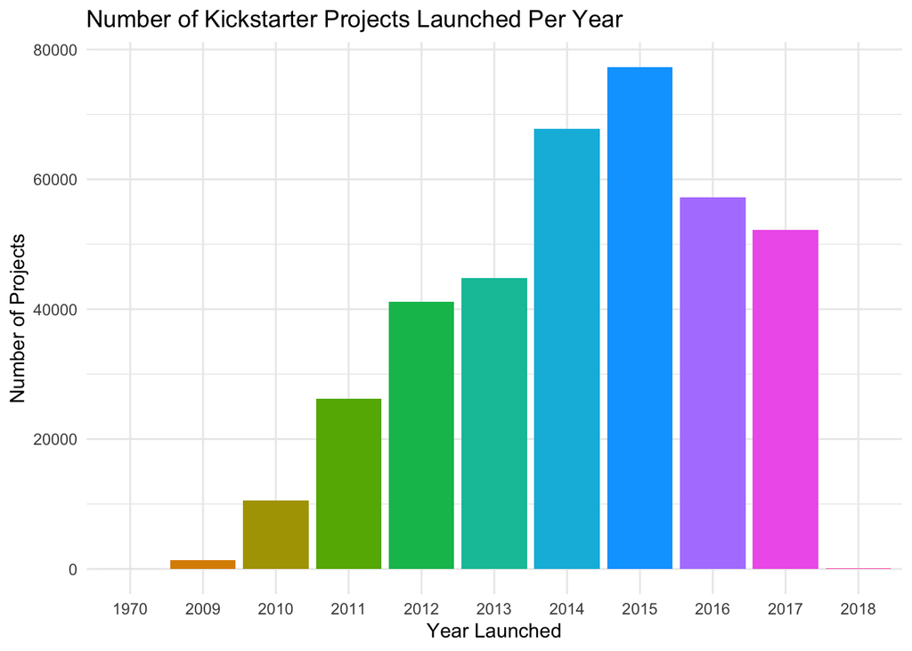

```r
ggplot(yearly_summary, aes(x = launched_year, y = count, fill = launched_year)) +
  geom_bar(stat = "identity") +
  labs(
    title = "Number of Kickstarter Projects Launched Per Year",
    x     = "Year Launched",
    y     = "Number of Projects"
  ) +
  theme_minimal() +
  theme(legend.position = "none")
```

The chart shows a peak in Kickstarter project launches around 2014–2015, after which the number of new projects declined. There is also a very small bar for 1970.

## Unusual Data Values

In the yearly summary bar chart, there is a bar representing projects launched in **1970** (before founding of Kickstarter). This is an example of a date value that likely defaulted to the Unix epoch when the timestamp was not recorded properly/was zero.

**Why it’s unusual:** Kickstarter did not exist in 1970, so a launch date of 1970 is impossible.

**One guess about why it’s there:** The `launched` column may store timestamps as Unix epoch integers in some cases, and a missing or null value defaults to 0, which corresponds to January 1, 1970 in Unix time, causing the date parser to assign that year.

**Follow-up question:** Were these records missing a launch date at the time of data collection, or did the Kickstarter platform itself record them with a zero timestamp? It would help to understand the root cause in order to decide to drop these rows or not (recovery).